# SuperKart Sales Revenue Forecasting and Deployment

## Full-code project

This notebook develops, tunes, evaluates, serializes, and operationalizes a machine-learning solution that forecasts `Product_Store_Sales_Total` for SuperKart's product-store combinations.

### Notebook roadmap

1. Business understanding and data overview
2. Exploratory data analysis
3. Data cleaning, feature engineering, and preprocessing
4. Model building and hyperparameter tuning
5. Final-model selection, test evaluation, and serialization
6. Flask backend, Streamlit frontend, Docker configuration, and inference tests
7. Actionable insights, recommendations, limitations, and next steps

## 1. Business Context and Objective

SuperKart is a retail chain operating supermarkets and food marts across tier cities. It wants to forecast product-store sales revenue for the upcoming quarter so that regional sales, procurement, and inventory decisions can be made consistently across its network.

The solution must do more than train a model: the final preprocessing-and-model pipeline must be serialized and exposed through a reliable API and a user-friendly application supporting both single and batch predictions.

> **Important modeling interpretation:** the supplied data is a cross-sectional product-store table with no date or time index. Therefore, this project estimates next-quarter revenue from product and outlet attributes; it is not a classical time-series model and cannot learn seasonality or temporal trends.

## 2. Environment and Imports

The deployment dependency files created later pin the same package versions used to serialize the model. If running this notebook in a fresh Colab environment, install the listed versions and restart the runtime before continuing.

```python
# Optional Colab setup (uncomment only in a fresh runtime):
# !pip install -q numpy==2.5.2 pandas==2.3.3 scikit-learn==1.8.0 \
#     matplotlib==3.10.8 seaborn==0.13.2 joblib==1.5.3 \
#     flask==3.1.2 gunicorn==23.0.0 streamlit==1.49.1 requests==2.34.2

import io
import json
import os
import sys
import warnings
from importlib import metadata
from pathlib import Path

import joblib
import matplotlib.pyplot as plt
import numpy as np
import pandas as pd
import seaborn as sns
from IPython.display import display
from sklearn.compose import ColumnTransformer
from sklearn.ensemble import GradientBoostingRegressor, RandomForestRegressor
from sklearn.impute import SimpleImputer
from sklearn.metrics import mean_absolute_error, mean_squared_error, r2_score
from sklearn.model_selection import GridSearchCV, train_test_split
from sklearn.pipeline import Pipeline
from sklearn.preprocessing import OneHotEncoder

warnings.filterwarnings("ignore")
pd.set_option("display.max_columns", None)
pd.set_option("display.float_format", lambda value: f"{value:,.3f}")
sns.set_theme(style="whitegrid", context="notebook")

RANDOM_STATE = 42
TARGET = "Product_Store_Sales_Total"
REFERENCE_YEAR = 2025

versions = {
    package: metadata.version(package)
    for package in ["numpy", "pandas", "scikit-learn", "matplotlib", "seaborn", "joblib"]
}
display(pd.Series(versions, name="Version").to_frame())
```

|  | Version |
| --- | --- |
| numpy | 2.5.2 |
| pandas | 2.3.3 |
| scikit-learn | 1.8.0 |
| matplotlib | 3.10.8 |
| seaborn | 0.13.2 |
| joblib | 1.5.3 |

## 3. Load the Dataset

The notebook expects `SuperKart.csv` and `Batch_Data_SuperKart.csv` in the same folder as the notebook. The batch file already uses the engineered feature schema required by the deployment model.

```python
DATA_PATH = Path("SuperKart.csv")
BATCH_PATH = Path("Batch_Data_SuperKart.csv")

if not DATA_PATH.exists():
    raise FileNotFoundError(
        "SuperKart.csv was not found. Place it in the notebook's working directory."
    )

raw_data = pd.read_csv(DATA_PATH)
print(f"Dataset loaded: {raw_data.shape[0]:,} rows x {raw_data.shape[1]} columns")
display(raw_data.head())
```

```
Dataset loaded: 8,763 rows x 12 columns
```

|  | Product_Id | Product_Weight | Product_Sugar_Content | Product_Allocated_Area | Product_Type | Product_MRP | Store_Id | Store_Establishment_Year | Store_Size | Store_Location_City_Type | Store_Type | Product_Store_Sales_Total |
| --- | --- | --- | --- | --- | --- | --- | --- | --- | --- | --- | --- | --- |
| 0 | FD6114 | 12.660 | Low Sugar | 0.027 | Frozen Foods | 117.080 | OUT004 | 2009 | Medium | Tier 2 | Supermarket Type2 | 2,842.400 |
| 1 | FD7839 | 16.540 | Low Sugar | 0.144 | Dairy | 171.430 | OUT003 | 1999 | Medium | Tier 1 | Departmental Store | 4,830.020 |
| 2 | FD5075 | 14.280 | Regular | 0.031 | Canned | 162.080 | OUT001 | 1987 | High | Tier 2 | Supermarket Type1 | 4,130.160 |
| 3 | FD8233 | 12.100 | Low Sugar | 0.112 | Baking Goods | 186.310 | OUT001 | 1987 | High | Tier 2 | Supermarket Type1 | 4,132.180 |
| 4 | NC1180 | 9.570 | No Sugar | 0.010 | Health and Hygiene | 123.670 | OUT002 | 1998 | Small | Tier 3 | Food Mart | 2,279.360 |

## 4. Data Overview

```python
overview = pd.DataFrame({
    "Data type": raw_data.dtypes.astype(str),
    "Non-null": raw_data.notna().sum(),
    "Missing": raw_data.isna().sum(),
    "Unique": raw_data.nunique(dropna=False),
})

print(f"Shape: {raw_data.shape}")
print(f"Duplicate rows: {raw_data.duplicated().sum():,}")
display(overview)

print("Numerical statistical summary")
display(raw_data.describe().T)

print("Categorical statistical summary")
display(raw_data.describe(include="object").T)
```

```
Shape: (8763, 12)
Duplicate rows: 0
Numerical statistical summary
Categorical statistical summary
```

|  | Data type | Non-null | Missing | Unique |
| --- | --- | --- | --- | --- |
| Product_Id | object | 8763 | 0 | 8763 |
| Product_Weight | float64 | 8763 | 0 | 1113 |
| Product_Sugar_Content | object | 8763 | 0 | 4 |
| Product_Allocated_Area | float64 | 8763 | 0 | 228 |
| Product_Type | object | 8763 | 0 | 16 |
| Product_MRP | float64 | 8763 | 0 | 6100 |
| Store_Id | object | 8763 | 0 | 4 |
| Store_Establishment_Year | int64 | 8763 | 0 | 4 |
| Store_Size | object | 8763 | 0 | 3 |
| Store_Location_City_Type | object | 8763 | 0 | 3 |
| Store_Type | object | 8763 | 0 | 4 |
| Product_Store_Sales_Total | float64 | 8763 | 0 | 8668 |

|  | count | mean | std | min | 25% | 50% | 75% | max |
| --- | --- | --- | --- | --- | --- | --- | --- | --- |
| Product_Weight | 8,763.000 | 12.654 | 2.217 | 4.000 | 11.150 | 12.660 | 14.180 | 22.000 |
| Product_Allocated_Area | 8,763.000 | 0.069 | 0.048 | 0.004 | 0.031 | 0.056 | 0.096 | 0.298 |
| Product_MRP | 8,763.000 | 147.033 | 30.694 | 31.000 | 126.160 | 146.740 | 167.585 | 266.000 |
| Store_Establishment_Year | 8,763.000 | 2,002.033 | 8.388 | 1,987.000 | 1,998.000 | 2,009.000 | 2,009.000 | 2,009.000 |
| Product_Store_Sales_Total | 8,763.000 | 3,464.004 | 1,065.630 | 33.000 | 2,761.715 | 3,452.340 | 4,145.165 | 8,000.000 |

|  | count | unique | top | freq |
| --- | --- | --- | --- | --- |
| Product_Id | 8763 | 8763 | FD6114 | 1 |
| Product_Sugar_Content | 8763 | 4 | Low Sugar | 4885 |
| Product_Type | 8763 | 16 | Fruits and Vegetables | 1249 |
| Store_Id | 8763 | 4 | OUT004 | 4676 |
| Store_Size | 8763 | 3 | Medium | 6025 |
| Store_Location_City_Type | 8763 | 3 | Tier 2 | 6262 |
| Store_Type | 8763 | 4 | Supermarket Type2 | 4676 |

### Data-overview observations

- The dataset contains **8,763 observations and 12 attributes**, including the continuous target.
- Five variables are numerical and seven are categorical before feature engineering.
- There are **no missing values and no duplicate rows**, so no rows need to be dropped or imputed during the analysis. Imputers are still included in the production pipeline to make inference resilient to future operational data gaps.
- `Product_Id` is unique at row level; using the full identifier would encourage memorization. Its two-character prefix carries the useful product family signal without the high cardinality.
- `Store_Id` has only four values and largely duplicates information already represented by store size, city tier, type, and age. It is removed to reduce identifier dependence and improve interpretability.
- `Product_Sugar_Content` contains an inconsistent `reg` label that must be standardized to `Regular`.

## 5. Data Cleaning

```python
data = raw_data.copy()

print("Sugar-content labels before cleaning:")
display(data["Product_Sugar_Content"].value_counts().to_frame("Count"))

data["Product_Sugar_Content"] = data["Product_Sugar_Content"].replace({
    "reg": "Regular",
    "low sugar": "Low Sugar",
})

print("Sugar-content labels after cleaning:")
display(data["Product_Sugar_Content"].value_counts().to_frame("Count"))
```

```
Sugar-content labels before cleaning:
Sugar-content labels after cleaning:
```

| Product_Sugar_Content | Count |
| --- | --- |
| Low Sugar | 4885 |
| Regular | 2251 |
| No Sugar | 1519 |
| reg | 108 |

| Product_Sugar_Content | Count |
| --- | --- |
| Low Sugar | 4885 |
| Regular | 2359 |
| No Sugar | 1519 |

## 6. Exploratory Data Analysis

### 6.1 Univariate analysis: numerical variables

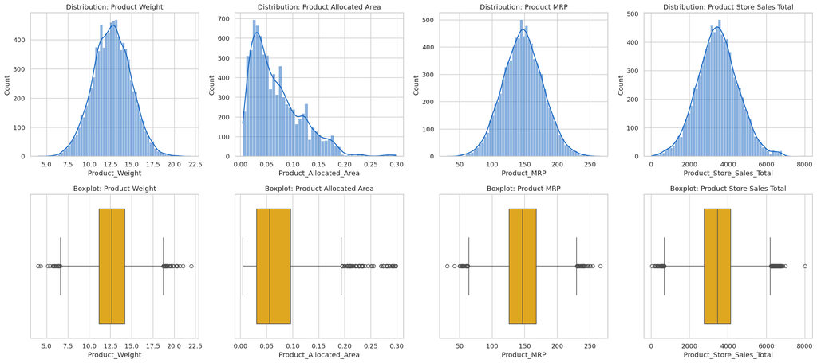

```python
plot_columns = [
    "Product_Weight",
    "Product_Allocated_Area",
    "Product_MRP",
    TARGET,
]

fig, axes = plt.subplots(2, 4, figsize=(20, 9))
for idx, column in enumerate(plot_columns):
    sns.histplot(data=data, x=column, kde=True, ax=axes[0, idx], color="#1565C0")
    axes[0, idx].set_title(f"Distribution: {column.replace('_', ' ')}")
    sns.boxplot(data=data, x=column, ax=axes[1, idx], color="#FFB300")
    axes[1, idx].set_title(f"Boxplot: {column.replace('_', ' ')}")

plt.tight_layout()
plt.show()
```

The key numerical variables are broadly centered with relatively small tails. `Product_Allocated_Area` is right-skewed because most products receive a small display share while a limited number receive much larger allocations. The target has a mean of about 3,464 revenue units, a median near 3,452, and a small number of legitimate high- and low-sales observations.

### 6.2 Univariate analysis: categorical variables

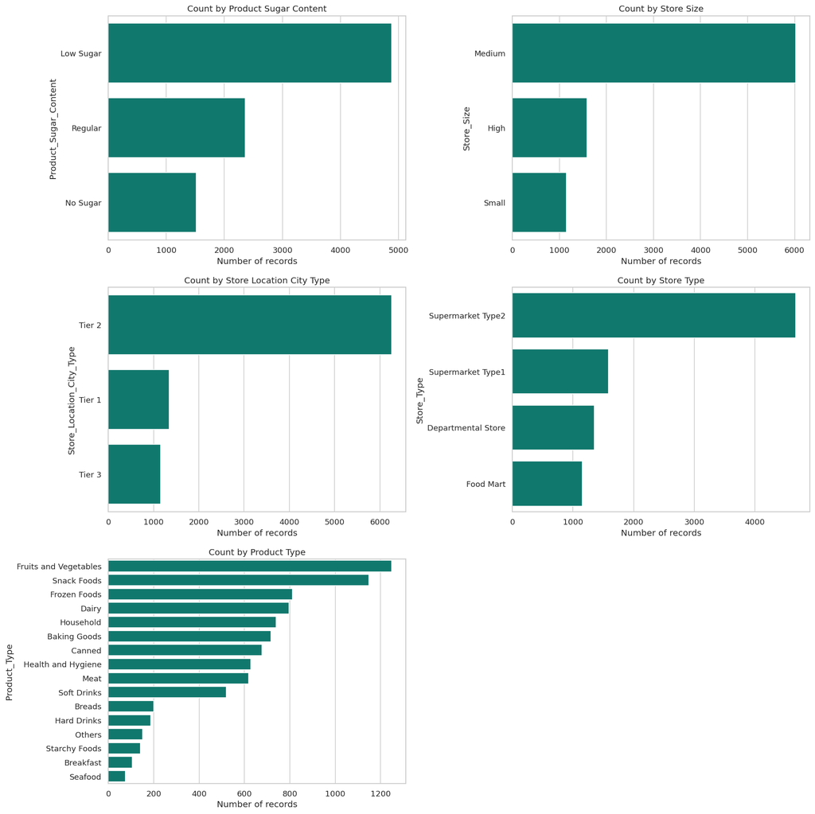

```python
categorical_plot_columns = [
    "Product_Sugar_Content",
    "Store_Size",
    "Store_Location_City_Type",
    "Store_Type",
    "Product_Type",
]

fig, axes = plt.subplots(3, 2, figsize=(16, 16))
axes = axes.flatten()
for axis, column in zip(axes, categorical_plot_columns):
    order = data[column].value_counts().index
    sns.countplot(data=data, y=column, order=order, ax=axis, color="#00897B")
    axis.set_title(f"Count by {column.replace('_', ' ')}")
    axis.set_xlabel("Number of records")

axes[-1].axis("off")
plt.tight_layout()
plt.show()
```

The data is concentrated in medium stores, Tier 2 cities, and Supermarket Type2 outlets. Low-sugar products are the largest sugar-content segment. These imbalances describe SuperKart's current portfolio and must be retained rather than artificially balanced because this is a regression problem and the distribution reflects operational exposure.

### 6.3 Bivariate and multivariate analysis

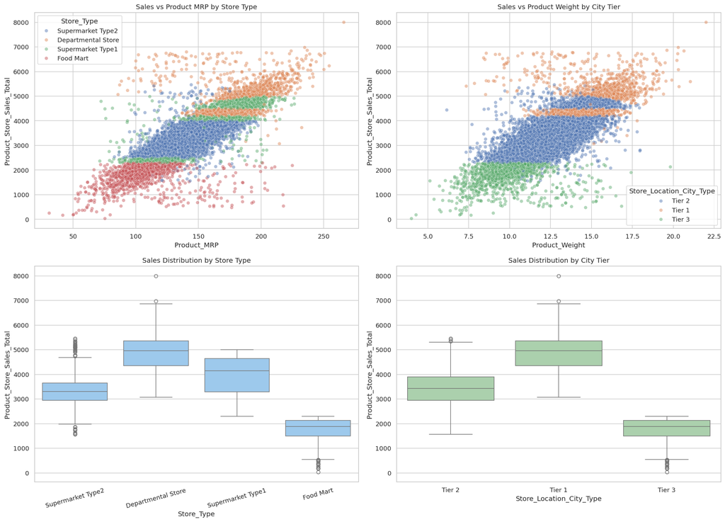

```python
fig, axes = plt.subplots(2, 2, figsize=(18, 13))

sns.scatterplot(
    data=data,
    x="Product_MRP",
    y=TARGET,
    hue="Store_Type",
    alpha=0.45,
    ax=axes[0, 0],
)
axes[0, 0].set_title("Sales vs Product MRP by Store Type")

sns.scatterplot(
    data=data,
    x="Product_Weight",
    y=TARGET,
    hue="Store_Location_City_Type",
    alpha=0.45,
    ax=axes[0, 1],
)
axes[0, 1].set_title("Sales vs Product Weight by City Tier")

sns.boxplot(data=data, x="Store_Type", y=TARGET, ax=axes[1, 0], color="#90CAF9")
axes[1, 0].tick_params(axis="x", rotation=15)
axes[1, 0].set_title("Sales Distribution by Store Type")

sns.boxplot(
    data=data,
    x="Store_Location_City_Type",
    y=TARGET,
    ax=axes[1, 1],
    color="#A5D6A7",
)
axes[1, 1].set_title("Sales Distribution by City Tier")

plt.tight_layout()
plt.show()
```

[output not shown]

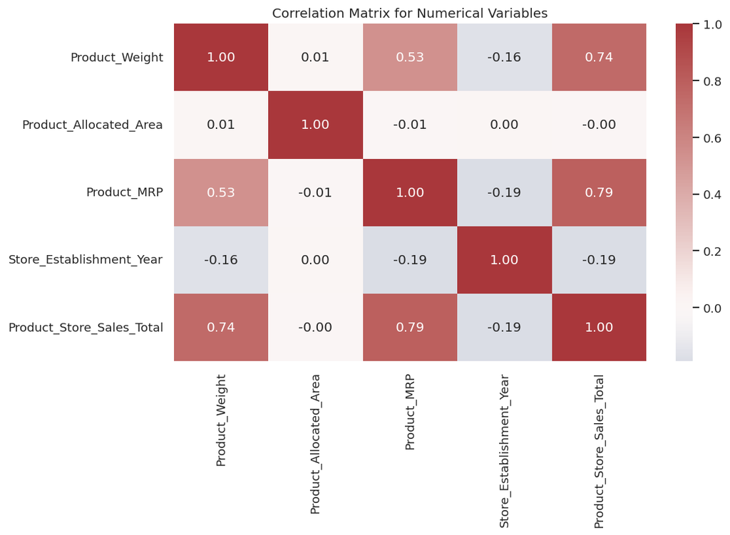

| Store_Type | Records | Mean_Sales | Median_Sales |
| --- | --- | --- | --- |
| Departmental Store | 1349 | 4,946.966 | 4,958.290 |
| Supermarket Type1 | 1586 | 3,923.779 | 4,139.645 |
| Supermarket Type2 | 4676 | 3,299.312 | 3,304.180 |
| Food Mart | 1152 | 1,762.942 | 1,889.495 |

| Store_Location_City_Type | Records | Mean_Sales | Median_Sales |
| --- | --- | --- | --- |
| Tier 1 | 1349 | 4,946.966 | 4,958.290 |
| Tier 2 | 6262 | 3,457.473 | 3,426.830 |
| Tier 3 | 1152 | 1,762.942 | 1,889.495 |

```python
numeric_corr = data.select_dtypes(include=np.number).corr()
plt.figure(figsize=(10, 7))
sns.heatmap(numeric_corr, annot=True, fmt=".2f", cmap="vlag", center=0)
plt.title("Correlation Matrix for Numerical Variables")
plt.tight_layout()
plt.show()

store_summary = (
    data.groupby("Store_Type", observed=True)[TARGET]
    .agg(Records="size", Mean_Sales="mean", Median_Sales="median")
    .sort_values("Mean_Sales", ascending=False)
)
city_summary = (
    data.groupby("Store_Location_City_Type", observed=True)[TARGET]
    .agg(Records="size", Mean_Sales="mean", Median_Sales="median")
    .sort_values("Mean_Sales", ascending=False)
)

print("Sales by store type")
display(store_summary)
print("Sales by city tier")
display(city_summary)
```

### EDA insights

- `Product_MRP` has the strongest direct linear association with sales (**r ≈ 0.79**), followed by `Product_Weight` (**r ≈ 0.74**). These are predictive relationships, not proof that increasing price or weight will cause sales to rise.
- Departmental stores average about **4,947** revenue units per product-store record, while Food Marts average about **1,763**. Outlet format and market tier should therefore be central to inventory segmentation.
- Tier 1 records have the highest mean sales (about **4,947**), Tier 2 records are intermediate (about **3,457**), and Tier 3 records are lowest (about **1,763**).
- `Product_Allocated_Area` has almost no overall linear correlation with sales (**r ≈ 0.00**). SuperKart should not assume that more shelf space automatically produces higher revenue without controlled product- and store-level tests.
- Sugar class and the broad perishability category show relatively small differences in average sales compared with price and store characteristics.
- Store attributes are structurally linked because the dataset contains only four outlets. The model is most defensible for product planning within these observed outlet patterns; predictions for completely new store configurations require additional validation.

## 7. Data Preprocessing

### 7.1 Outlier detection and treatment decision

```python
outlier_columns = [
    "Product_Weight",
    "Product_Allocated_Area",
    "Product_MRP",
    TARGET,
]

outlier_rows = []
for column in outlier_columns:
    q1 = data[column].quantile(0.25)
    q3 = data[column].quantile(0.75)
    iqr = q3 - q1
    lower = q1 - 1.5 * iqr
    upper = q3 + 1.5 * iqr
    count = ((data[column] < lower) | (data[column] > upper)).sum()
    outlier_rows.append({
        "Feature": column,
        "Lower IQR fence": lower,
        "Upper IQR fence": upper,
        "Outlier count": int(count),
        "Outlier %": 100 * count / len(data),
    })

outlier_summary = pd.DataFrame(outlier_rows).set_index("Feature")
display(outlier_summary)
```

| Feature | Lower IQR fence | Upper IQR fence | Outlier count | Outlier % |
| --- | --- | --- | --- | --- |
| Product_Weight | 6.605 | 18.725 | 54 | 0.616 |
| Product_Allocated_Area | -0.067 | 0.194 | 104 | 1.187 |
| Product_MRP | 64.022 | 229.723 | 57 | 0.650 |
| Product_Store_Sales_Total | 686.540 | 6,220.340 | 119 | 1.358 |

**Treatment decision:** no outliers are removed or capped. The IQR-flagged observations are a small share of the data and remain within plausible physical, pricing, display-area, and sales ranges. High-sales records are especially valuable to the business and should not be erased. Both selected models are tree ensembles, which are substantially less sensitive to extreme feature magnitudes than distance- or coefficient-based models. Input-range validation is applied at the API boundary to reject impossible operational values.

### 7.2 Feature engineering

```python
def engineer_features(frame: pd.DataFrame) -> pd.DataFrame:
    '''Create compact, business-meaningful features from raw product/store fields.'''
    result = frame.copy()
    result["Product_Sugar_Content"] = result["Product_Sugar_Content"].replace({
        "reg": "Regular",
        "low sugar": "Low Sugar",
    })
    result["Product_Id_char"] = result["Product_Id"].str[:2]
    result["Store_Age_Years"] = REFERENCE_YEAR - result["Store_Establishment_Year"]

    perishables = {
        "Dairy",
        "Meat",
        "Fruits and Vegetables",
        "Breakfast",
        "Breads",
        "Seafood",
    }
    result["Product_Type_Category"] = np.where(
        result["Product_Type"].isin(perishables),
        "Perishables",
        "Non Perishables",
    )

    return result.drop(
        columns=["Product_Id", "Product_Type", "Store_Id", "Store_Establishment_Year"]
    )


model_data = engineer_features(data)
FEATURE_COLUMNS = [column for column in model_data.columns if column != TARGET]

print("Model features:")
print(FEATURE_COLUMNS)
display(model_data.head())
```

```
Model features:
['Product_Weight', 'Product_Sugar_Content', 'Product_Allocated_Area', 'Product_MRP', 'Store_Size', 'Store_Location_City_Type', 'Store_Type', 'Product_Id_char', 'Store_Age_Years', 'Product_Type_Category']
```

|  | Product_Weight | Product_Sugar_Content | Product_Allocated_Area | Product_MRP | Store_Size | Store_Location_City_Type | Store_Type | Product_Store_Sales_Total | Product_Id_char | Store_Age_Years | Product_Type_Category |
| --- | --- | --- | --- | --- | --- | --- | --- | --- | --- | --- | --- |
| 0 | 12.660 | Low Sugar | 0.027 | 117.080 | Medium | Tier 2 | Supermarket Type2 | 2,842.400 | FD | 16 | Non Perishables |
| 1 | 16.540 | Low Sugar | 0.144 | 171.430 | Medium | Tier 1 | Departmental Store | 4,830.020 | FD | 26 | Perishables |
| 2 | 14.280 | Regular | 0.031 | 162.080 | High | Tier 2 | Supermarket Type1 | 4,130.160 | FD | 38 | Non Perishables |
| 3 | 12.100 | Low Sugar | 0.112 | 186.310 | High | Tier 2 | Supermarket Type1 | 4,132.180 | FD | 38 | Non Perishables |
| 4 | 9.570 | No Sugar | 0.010 | 123.670 | Small | Tier 3 | Food Mart | 2,279.360 | NC | 27 | Non Perishables |

Feature-engineering rationale:

- `Product_Id_char` retains the meaningful FD/DR/NC product family while avoiding the 8,763-level full identifier.
- `Store_Age_Years = 2025 - Store_Establishment_Year` gives the model an interpretable operational-age measure. The fixed reference year keeps training and deployment consistent.
- Six product types with short shelf life are grouped as `Perishables`; the remaining types are `Non Perishables`. This reduces category fragmentation and matches the supplied batch-inference schema.
- `Store_Id`, the full product ID, raw product type, and establishment year are dropped after their useful information is represented in lower-cardinality or derived fields.

### 7.3 Train, validation, and test sets

```python
X = model_data[FEATURE_COLUMNS].copy()
y = model_data[TARGET].copy()

# Hold out 15% once for the final unbiased test. Split the remaining 85% into
# approximately 70% training and 15% validation.
X_development, X_test, y_development, y_test = train_test_split(
    X,
    y,
    test_size=0.15,
    random_state=RANDOM_STATE,
)
validation_fraction_of_development = 0.15 / 0.85
X_train, X_validation, y_train, y_validation = train_test_split(
    X_development,
    y_development,
    test_size=validation_fraction_of_development,
    random_state=RANDOM_STATE,
)

split_summary = pd.DataFrame({
    "Rows": [len(X_train), len(X_validation), len(X_test)],
    "Share": [len(X_train) / len(X), len(X_validation) / len(X), len(X_test) / len(X)],
}, index=["Train", "Validation", "Test"])
display(split_summary)
```

|  | Rows | Share |
| --- | --- | --- |
| Train | 6133 | 0.700 |
| Validation | 1315 | 0.150 |
| Test | 1315 | 0.150 |

### 7.4 Preprocessing pipeline

```python
numeric_features = X.select_dtypes(include=np.number).columns.tolist()
categorical_features = X.select_dtypes(exclude=np.number).columns.tolist()

numeric_pipeline = Pipeline(steps=[
    ("imputer", SimpleImputer(strategy="median")),
])

categorical_pipeline = Pipeline(steps=[
    ("imputer", SimpleImputer(strategy="most_frequent")),
    ("onehot", OneHotEncoder(handle_unknown="ignore", sparse_output=False)),
])

preprocessor = ColumnTransformer(
    transformers=[
        ("numeric", numeric_pipeline, numeric_features),
        ("categorical", categorical_pipeline, categorical_features),
    ],
    verbose_feature_names_out=False,
)

print("Numerical features:", numeric_features)
print("Categorical features:", categorical_features)
print("The transformer is fitted only inside each model/CV fold, preventing data leakage.")
```

```
Numerical features: ['Product_Weight', 'Product_Allocated_Area', 'Product_MRP', 'Store_Age_Years']
Categorical features: ['Product_Sugar_Content', 'Store_Size', 'Store_Location_City_Type', 'Store_Type', 'Product_Id_char', 'Product_Type_Category']
The transformer is fitted only inside each model/CV fold, preventing data leakage.
```

## 8. Model Building

### Metric of choice: RMSE

Root Mean Squared Error (RMSE) is the primary selection metric because it is expressed in the same revenue units as the target and penalizes large misses more heavily. Large forecast errors can create costly stockouts, overstock, and regional allocation mistakes. MAE is reported as an easy-to-interpret typical absolute error, while R² indicates the share of target variance explained. MAPE is not used for selection because the target includes relatively small values, which can make percentage errors unstable and disproportionately large.

```python
def regression_metrics(model, predictors, target):
    predictions = model.predict(predictors)
    return {
        "RMSE": mean_squared_error(target, predictions) ** 0.5,
        "MAE": mean_absolute_error(target, predictions),
        "R-squared": r2_score(target, predictions),
    }


def evaluate_train_validation(model, model_name):
    train_metrics = regression_metrics(model, X_train, y_train)
    validation_metrics = regression_metrics(model, X_validation, y_validation)
    return pd.DataFrame(
        [train_metrics, validation_metrics],
        index=pd.MultiIndex.from_tuples(
            [(model_name, "Train"), (model_name, "Validation")],
            names=["Model", "Dataset"],
        ),
    )
```

### 8.1 Base Random Forest and Gradient Boosting pipelines

```python
random_forest_pipeline = Pipeline(steps=[
    ("preprocessor", preprocessor),
    ("model", RandomForestRegressor(
        n_estimators=250,
        random_state=RANDOM_STATE,
        n_jobs=-1,
    )),
])

gradient_boosting_pipeline = Pipeline(steps=[
    ("preprocessor", preprocessor),
    ("model", GradientBoostingRegressor(random_state=RANDOM_STATE)),
])

base_models = {
    "Random Forest - Base": random_forest_pipeline,
    "Gradient Boosting - Base": gradient_boosting_pipeline,
}

base_performance_parts = []
for model_name, model in base_models.items():
    model.fit(X_train, y_train)
    base_performance_parts.append(evaluate_train_validation(model, model_name))

base_performance = pd.concat(base_performance_parts)
display(base_performance)
```

| Model | Dataset | RMSE | MAE | R-squared |
| --- | --- | --- | --- | --- |
| Random Forest - Base | Train | 104.774 | 39.426 | 0.990 |
|  | Validation | 290.168 | 105.362 | 0.926 |
| Gradient Boosting - Base | Train | 296.137 | 138.245 | 0.923 |
|  | Validation | 318.611 | 144.373 | 0.911 |

The base Random Forest fits the training data much more closely than the validation data, indicating variance/overfitting. Gradient Boosting has a smaller train-validation gap but higher validation RMSE. Hyperparameter tuning will regularize the Random Forest and improve the Gradient Boosting learning configuration.

## 9. Model Performance Improvement: Hyperparameter Tuning

```python
rf_parameter_grid = {
    "model__n_estimators": [200],
    "model__max_depth": [None, 14],
    "model__min_samples_leaf": [1, 2, 4],
    "model__max_features": [0.8, 1.0],
}

gb_parameter_grid = {
    "model__n_estimators": [150, 250],
    "model__learning_rate": [0.04, 0.08],
    "model__max_depth": [2, 3],
    "model__min_samples_leaf": [3, 8],
}

rf_search = GridSearchCV(
    estimator=random_forest_pipeline,
    param_grid=rf_parameter_grid,
    scoring="neg_root_mean_squared_error",
    cv=3,
    n_jobs=1,
    return_train_score=True,
)

gb_search = GridSearchCV(
    estimator=gradient_boosting_pipeline,
    param_grid=gb_parameter_grid,
    scoring="neg_root_mean_squared_error",
    cv=3,
    n_jobs=1,
    return_train_score=True,
)

print("Tuning Random Forest...")
rf_search.fit(X_train, y_train)
print("Tuning Gradient Boosting...")
gb_search.fit(X_train, y_train)

tuning_summary = pd.DataFrame({
    "Best CV RMSE": [-rf_search.best_score_, -gb_search.best_score_],
    "Best parameters": [rf_search.best_params_, gb_search.best_params_],
}, index=["Random Forest - Tuned", "Gradient Boosting - Tuned"])
display(tuning_summary)
```

```
Tuning Random Forest...
Tuning Gradient Boosting...
```

|  | Best CV RMSE | Best parameters |
| --- | --- | --- |
| Random Forest - Tuned | 283.335 | {'model__max_depth': None, 'model__max_features': 0.8, 'model__min_samples_leaf': 2, 'model__n_estimators': 200} |
| Gradient Boosting - Tuned | 312.594 | {'model__learning_rate': 0.08, 'model__max_depth': 3, 'model__min_samples_leaf': 3, 'model__n_estimators': 250} |

```python
tuned_models = {
    "Random Forest - Tuned": rf_search.best_estimator_,
    "Gradient Boosting - Tuned": gb_search.best_estimator_,
}

tuned_performance_parts = []
for model_name, model in tuned_models.items():
    tuned_performance_parts.append(evaluate_train_validation(model, model_name))

tuned_performance = pd.concat(tuned_performance_parts)
display(tuned_performance)
```

| Model | Dataset | RMSE | MAE | R-squared |
| --- | --- | --- | --- | --- |
| Random Forest - Tuned | Train | 170.137 | 61.692 | 0.975 |
|  | Validation | 287.641 | 105.638 | 0.927 |
| Gradient Boosting - Tuned | Train | 272.465 | 118.143 | 0.935 |
|  | Validation | 309.620 | 131.674 | 0.915 |

Tuning reduces the Random Forest train-validation gap by increasing the minimum leaf size and/or limiting feature sampling, while the tuned Gradient Boosting configuration improves over its default baseline. Model selection below uses cross-validated training RMSE first and validation performance as a consistency check; the untouched test set is not consulted until a single final model has been selected.

## 10. Model Comparison, Final Selection, and Serialization

```python
comparison_rows = []
for model_name, model in {**base_models, **tuned_models}.items():
    train_values = regression_metrics(model, X_train, y_train)
    validation_values = regression_metrics(model, X_validation, y_validation)
    comparison_rows.append({
        "Model": model_name,
        "Train RMSE": train_values["RMSE"],
        "Validation RMSE": validation_values["RMSE"],
        "Validation MAE": validation_values["MAE"],
        "Validation R-squared": validation_values["R-squared"],
        "CV RMSE": (
            -rf_search.best_score_ if model_name == "Random Forest - Tuned"
            else -gb_search.best_score_ if model_name == "Gradient Boosting - Tuned"
            else np.nan
        ),
    })

model_comparison = pd.DataFrame(comparison_rows).set_index("Model")
display(model_comparison.sort_values("Validation RMSE"))

selected_model_name = min(
    ["Random Forest - Tuned", "Gradient Boosting - Tuned"],
    key=lambda name: model_comparison.loc[name, "CV RMSE"],
)
selected_model = tuned_models[selected_model_name]
print(f"Selected model: {selected_model_name}")
```

```
Selected model: Random Forest - Tuned
```

| Model | Train RMSE | Validation RMSE | Validation MAE | Validation R-squared | CV RMSE |
| --- | --- | --- | --- | --- | --- |
| Random Forest - Tuned | 170.137 | 287.641 | 105.638 | 0.927 | 283.335 |
| Random Forest - Base | 104.774 | 290.168 | 105.362 | 0.926 | NaN |
| Gradient Boosting - Tuned | 272.465 | 309.620 | 131.674 | 0.915 | 312.594 |
| Gradient Boosting - Base | 296.137 | 318.611 | 144.373 | 0.911 | NaN |

The tuned Random Forest is selected because it produces the lowest cross-validated RMSE and the strongest validation RMSE/R² among the tuned candidates. Its larger leaf size reduces overfitting relative to the base forest, while averaging many decorrelated trees supports stable nonlinear predictions. Although Gradient Boosting is more compact, its error is consistently higher on this dataset.

### 10.1 Final performance on the untouched test set

```
Final test RMSE: 267.61 | MAE: 101.56 | R-squared: 0.9369
```

|  | RMSE | MAE | R-squared |
| --- | --- | --- | --- |
| Random Forest - Tuned | 267.613 | 101.556 | 0.937 |

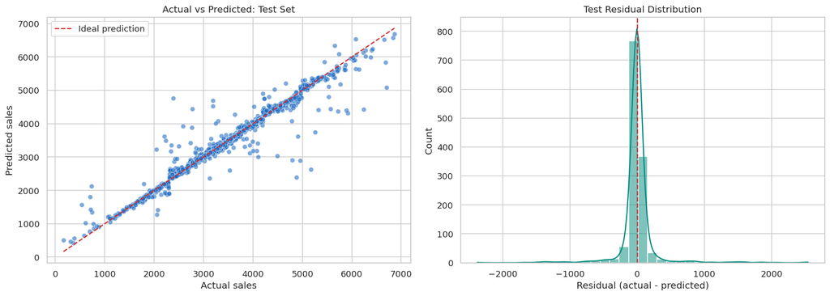

```python
test_metrics = regression_metrics(selected_model, X_test, y_test)
test_performance = pd.DataFrame([test_metrics], index=[selected_model_name])
display(test_performance)

test_predictions = selected_model.predict(X_test)
residuals = y_test.to_numpy() - test_predictions

fig, axes = plt.subplots(1, 2, figsize=(15, 5.5))
sns.scatterplot(x=y_test, y=test_predictions, alpha=0.55, ax=axes[0], color="#1565C0")
limits = [min(y_test.min(), test_predictions.min()), max(y_test.max(), test_predictions.max())]
axes[0].plot(limits, limits, "--", color="#D32F2F", label="Ideal prediction")
axes[0].set_xlabel("Actual sales")
axes[0].set_ylabel("Predicted sales")
axes[0].set_title("Actual vs Predicted: Test Set")
axes[0].legend()

sns.histplot(residuals, kde=True, bins=35, ax=axes[1], color="#00897B")
axes[1].axvline(0, linestyle="--", color="#D32F2F")
axes[1].set_xlabel("Residual (actual - predicted)")
axes[1].set_title("Test Residual Distribution")
plt.tight_layout()
plt.show()

print(
    f"Final test RMSE: {test_metrics['RMSE']:,.2f} | "
    f"MAE: {test_metrics['MAE']:,.2f} | "
    f"R-squared: {test_metrics['R-squared']:.4f}"
)
```

### 10.2 Feature importance

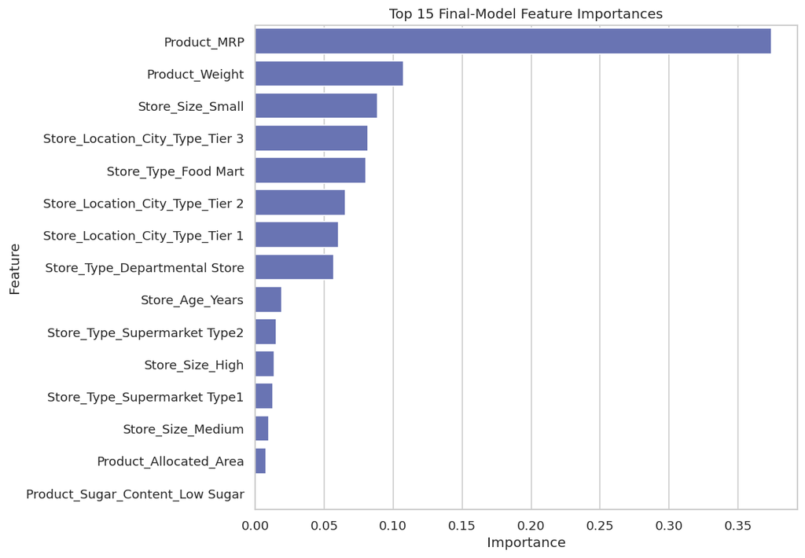

|  | Feature | Importance |
| --- | --- | --- |
| 2 | Product_MRP | 0.374 |
| 0 | Product_Weight | 0.108 |
| 9 | Store_Size_Small | 0.089 |
| 12 | Store_Location_City_Type_Tier 3 | 0.082 |
| 14 | Store_Type_Food Mart | 0.080 |
| 11 | Store_Location_City_Type_Tier 2 | 0.065 |
| 10 | Store_Location_City_Type_Tier 1 | 0.060 |
| 13 | Store_Type_Departmental Store | 0.057 |
| 3 | Store_Age_Years | 0.020 |
| 16 | Store_Type_Supermarket Type2 | 0.016 |
| 7 | Store_Size_High | 0.014 |
| 15 | Store_Type_Supermarket Type1 | 0.013 |
| 8 | Store_Size_Medium | 0.010 |
| 1 | Product_Allocated_Area | 0.008 |
| 4 | Product_Sugar_Content_Low Sugar | 0.001 |

```python
fitted_preprocessor = selected_model.named_steps["preprocessor"]
feature_names = fitted_preprocessor.get_feature_names_out()
importances = selected_model.named_steps["model"].feature_importances_

feature_importance = (
    pd.DataFrame({"Feature": feature_names, "Importance": importances})
    .sort_values("Importance", ascending=False)
    .head(15)
)

plt.figure(figsize=(10, 7))
sns.barplot(data=feature_importance, x="Importance", y="Feature", color="#5C6BC0")
plt.title("Top 15 Final-Model Feature Importances")
plt.tight_layout()
plt.show()
display(feature_importance)
```

### 10.3 Serialize and reload the complete pipeline

```python
PROJECT_ROOT = Path.cwd()
BACKEND_DIR = PROJECT_ROOT / "backend_files"
FRONTEND_DIR = PROJECT_ROOT / "frontend_files"
BACKEND_DIR.mkdir(exist_ok=True)
FRONTEND_DIR.mkdir(exist_ok=True)

MODEL_PATH = BACKEND_DIR / "superkart_model.joblib"
joblib.dump(selected_model, MODEL_PATH, compress=3)
loaded_model = joblib.load(MODEL_PATH)

reloaded_predictions = loaded_model.predict(X_test)
maximum_difference = np.max(np.abs(reloaded_predictions - test_predictions))

print(f"Serialized pipeline: {MODEL_PATH}")
print(f"File size: {MODEL_PATH.stat().st_size / (1024 ** 2):.2f} MB")
print(f"Maximum prediction difference after reload: {maximum_difference:.12f}")
assert maximum_difference < 1e-9
```

```
Serialized pipeline: /workspace/scratch/25d0cfd9984e/outputs/superkart_project/backend_files/superkart_model.joblib
File size: 13.70 MB
Maximum prediction difference after reload: 0.000000000002
```

## 11. Deployment - Flask Backend

The backend exposes a health endpoint plus separate POST endpoints for single and batch inference. It validates required columns, numeric types, and plausible ranges before passing data to the serialized pipeline. Errors return JSON with an appropriate HTTP status rather than an HTML stack trace.

```python
backend_app = r'''from pathlib import Path

import joblib
import numpy as np
import pandas as pd
from flask import Flask, jsonify, request


BASE_DIR = Path(__file__).resolve().parent
MODEL_PATH = BASE_DIR / "superkart_model.joblib"
MODEL_FEATURES = [
    "Product_Weight",
    "Product_Sugar_Content",
    "Product_Allocated_Area",
    "Product_MRP",
    "Store_Size",
    "Store_Location_City_Type",
    "Store_Type",
    "Product_Id_char",
    "Store_Age_Years",
    "Product_Type_Category",
]
NUMERIC_FEATURES = [
    "Product_Weight",
    "Product_Allocated_Area",
    "Product_MRP",
    "Store_Age_Years",
]

app = Flask(__name__)
app.config["MAX_CONTENT_LENGTH"] = 5 * 1024 * 1024
model = joblib.load(MODEL_PATH)


def validate_records(records):
    if not records:
        raise ValueError("At least one input record is required.")

    frame = pd.DataFrame(records)
    missing = [column for column in MODEL_FEATURES if column not in frame.columns]
    if missing:
        raise ValueError(f"Missing required columns: {missing}")

    frame = frame[MODEL_FEATURES].copy()
    for column in NUMERIC_FEATURES:
        frame[column] = pd.to_numeric(frame[column], errors="raise")

    if not np.isfinite(frame[NUMERIC_FEATURES].to_numpy()).all():
        raise ValueError("Numeric values must be finite.")
    if (frame["Product_Weight"] <= 0).any():
        raise ValueError("Product_Weight must be greater than zero.")
    if ((frame["Product_Allocated_Area"] < 0) | (frame["Product_Allocated_Area"] > 1)).any():
        raise ValueError("Product_Allocated_Area must be between 0 and 1.")
    if (frame["Product_MRP"] <= 0).any():
        raise ValueError("Product_MRP must be greater than zero.")
    if (frame["Store_Age_Years"] < 0).any():
        raise ValueError("Store_Age_Years cannot be negative.")
    return frame


@app.get("/")
def home():
    return jsonify({
        "service": "SuperKart Sales Forecasting API",
        "status": "ready",
        "endpoints": ["/health", "/v1/predict", "/v1/predictbatch"],
    })


@app.get("/health")
def health():
    return jsonify({"status": "healthy", "model_loaded": True})


@app.post("/v1/predict")
def predict():
    try:
        payload = request.get_json(silent=False)
        if not isinstance(payload, dict):
            raise ValueError("The JSON body must contain one input object.")
        frame = validate_records([payload])
        prediction = float(model.predict(frame)[0])
        return jsonify({"prediction": round(prediction, 2)})
    except (ValueError, TypeError, KeyError) as error:
        return jsonify({"error": str(error)}), 400


@app.post("/v1/predictbatch")
def predict_batch():
    try:
        if "file" not in request.files:
            raise ValueError("Upload a CSV file using the form field named 'file'.")
        uploaded = request.files["file"]
        if not uploaded.filename.lower().endswith(".csv"):
            raise ValueError("Only CSV files are supported.")
        batch_frame = pd.read_csv(uploaded)
        validated = validate_records(batch_frame.to_dict(orient="records"))
        predictions = model.predict(validated)
        return jsonify({
            "count": int(len(predictions)),
            "predictions": [round(float(value), 2) for value in predictions],
        })
    except (ValueError, TypeError, KeyError, pd.errors.ParserError) as error:
        return jsonify({"error": str(error)}), 400


@app.errorhandler(413)
def file_too_large(_error):
    return jsonify({"error": "Uploaded file exceeds the 5 MB limit."}), 413


if __name__ == "__main__":
    port = int(os.getenv("PORT", "7860"))
    app.run(host="0.0.0.0", port=port, debug=False)
'''

(BACKEND_DIR / "app.py").write_text(backend_app, encoding="utf-8")
print((BACKEND_DIR / "app.py").read_text(encoding="utf-8")[:1200])
```

[output not shown]

### 11.1 Backend dependencies

```python
backend_requirements = """flask==3.1.2
gunicorn==23.0.0
joblib==1.5.3
numpy==2.5.2
pandas==2.3.3
scikit-learn==1.8.0
"""
(BACKEND_DIR / "requirements.txt").write_text(backend_requirements, encoding="utf-8")
print(backend_requirements)
```

```
flask==3.1.2
gunicorn==23.0.0
joblib==1.5.3
numpy==2.5.2
pandas==2.3.3
scikit-learn==1.8.0
```

### 11.2 Backend Dockerfile

```python
backend_dockerfile = """FROM python:3.12-slim

ENV PYTHONDONTWRITEBYTECODE=1 \\
    PYTHONUNBUFFERED=1 \\
    PORT=7860

WORKDIR /app

COPY requirements.txt .
RUN pip install --no-cache-dir -r requirements.txt

COPY app.py superkart_model.joblib ./

RUN useradd --create-home --uid 10001 appuser && chown -R appuser:appuser /app
USER appuser

EXPOSE 7860

HEALTHCHECK --interval=30s --timeout=5s --start-period=20s --retries=3 \\
  CMD python -c "import urllib.request; urllib.request.urlopen('http://localhost:7860/health', timeout=3)" || exit 1

CMD ["gunicorn", "--workers", "2", "--bind", "0.0.0.0:7860", "--timeout", "120", "app:app"]
"""
(BACKEND_DIR / "Dockerfile").write_text(backend_dockerfile, encoding="utf-8")
print(backend_dockerfile)
```

```
FROM python:3.12-slim

ENV PYTHONDONTWRITEBYTECODE=1 \
    PYTHONUNBUFFERED=1 \
    PORT=7860

WORKDIR /app

COPY requirements.txt .
RUN pip install --no-cache-dir -r requirements.txt

COPY app.py superkart_model.joblib ./

RUN useradd --create-home --uid 10001 appuser && chown -R appuser:appuser /app
USER appuser

EXPOSE 7860

HEALTHCHECK --interval=30s --timeout=5s --start-period=20s --retries=3 \
  CMD python -c "import urllib.request; urllib.request.urlopen('http://localhost:7860/health', timeout=3)" || exit 1

CMD ["gunicorn", "--workers", "2", "--bind", "0.0.0.0:7860", "--timeout", "120", "app:app"]
```

## 12. Deployment - Streamlit Frontend

```python
frontend_app = r'''import io
import os

import pandas as pd
import requests
import streamlit as st


BACKEND_URL = os.getenv("BACKEND_URL", "http://localhost:7860").rstrip("/")
REQUIRED_COLUMNS = [
    "Product_Weight",
    "Product_Sugar_Content",
    "Product_Allocated_Area",
    "Product_MRP",
    "Store_Size",
    "Store_Location_City_Type",
    "Store_Type",
    "Product_Id_char",
    "Store_Age_Years",
    "Product_Type_Category",
]

st.set_page_config(page_title="SuperKart Forecast", page_icon="🛒", layout="wide")
st.title("🛒 SuperKart Quarterly Sales Forecast")
st.caption("Forecast product-store revenue using the deployed ensemble model.")

single_tab, batch_tab, about_tab = st.tabs(["Single prediction", "Batch prediction", "Model notes"])

with single_tab:
    st.subheader("Product and store details")
    with st.form("single_prediction_form"):
        product_col, store_col = st.columns(2)
        with product_col:
            product_weight = st.number_input("Product weight", min_value=0.01, value=12.66, step=0.10)
            sugar_content = st.selectbox("Sugar content", ["Low Sugar", "Regular", "No Sugar"])
            allocated_area = st.number_input(
                "Allocated display-area ratio", min_value=0.0, max_value=1.0, value=0.027, step=0.001, format="%.3f"
            )
            product_mrp = st.number_input("Product MRP", min_value=0.01, value=117.08, step=1.0)
            product_family = st.selectbox("Product ID family", ["FD", "DR", "NC"])
        with store_col:
            store_size = st.selectbox("Store size", ["Small", "Medium", "High"])
            city_tier = st.selectbox("Store city tier", ["Tier 1", "Tier 2", "Tier 3"])
            store_type = st.selectbox(
                "Store type",
                ["Supermarket Type1", "Supermarket Type2", "Departmental Store", "Food Mart"],
            )
            store_age = st.number_input("Store age (years)", min_value=0, value=16, step=1)
            product_category = st.selectbox("Product type category", ["Perishables", "Non Perishables"])
        submitted = st.form_submit_button("Forecast sales", type="primary", use_container_width=True)

    if submitted:
        payload = {
            "Product_Weight": product_weight,
            "Product_Sugar_Content": sugar_content,
            "Product_Allocated_Area": allocated_area,
            "Product_MRP": product_mrp,
            "Store_Size": store_size,
            "Store_Location_City_Type": city_tier,
            "Store_Type": store_type,
            "Product_Id_char": product_family,
            "Store_Age_Years": store_age,
            "Product_Type_Category": product_category,
        }
        try:
            with st.spinner("Generating forecast..."):
                response = requests.post(f"{BACKEND_URL}/v1/predict", json=payload, timeout=30)
                response.raise_for_status()
            prediction = response.json()["prediction"]
            st.success("Forecast completed")
            st.metric("Predicted product-store sales revenue", f"{prediction:,.2f}")
        except requests.RequestException as error:
            detail = error.response.json().get("error") if error.response is not None else str(error)
            st.error(f"Prediction request failed: {detail}")

with batch_tab:
    st.subheader("Upload a CSV for batch inference")
    st.write("Required columns:", ", ".join(REQUIRED_COLUMNS))
    uploaded_file = st.file_uploader("Batch CSV", type=["csv"])
    if uploaded_file is not None:
        batch_data = pd.read_csv(uploaded_file)
        st.dataframe(batch_data.head(10), use_container_width=True)
        missing = [column for column in REQUIRED_COLUMNS if column not in batch_data.columns]
        if missing:
            st.error(f"Missing required columns: {missing}")
        elif st.button("Run batch forecast", type="primary"):
            csv_bytes = batch_data.to_csv(index=False).encode("utf-8")
            files = {"file": ("batch.csv", io.BytesIO(csv_bytes), "text/csv")}
            try:
                with st.spinner("Forecasting batch..."):
                    response = requests.post(
                        f"{BACKEND_URL}/v1/predictbatch",
                        files=files,
                        timeout=120,
                    )
                    response.raise_for_status()
                result = response.json()
                output = batch_data.copy()
                output["Predicted_Product_Store_Sales_Total"] = result["predictions"]
                st.success(f"Generated {result['count']:,} forecasts")
                st.dataframe(output, use_container_width=True)
                st.download_button(
                    "Download predictions",
                    output.to_csv(index=False).encode("utf-8"),
                    file_name="SuperKart_Batch_Predictions.csv",
                    mime="text/csv",
                )
            except requests.RequestException as error:
                detail = error.response.json().get("error") if error.response is not None else str(error)
                st.error(f"Batch request failed: {detail}")

with about_tab:
    st.markdown(
        "**Model:** tuned Random Forest with an embedded preprocessing pipeline.  \n"
        "**Use:** planning support for product-store revenue and inventory decisions.  \n"
        "**Caution:** predictions are estimates, not guarantees. New store formats, unusual "
        "values, or changing market conditions require review and model monitoring."
    )
'''

(FRONTEND_DIR / "app.py").write_text(frontend_app, encoding="utf-8")
print((FRONTEND_DIR / "app.py").read_text(encoding="utf-8")[:1200])
```

[output not shown]

### 12.1 Frontend dependencies

```python
frontend_requirements = """pandas==2.3.3
requests==2.34.2
streamlit==1.49.1
"""
(FRONTEND_DIR / "requirements.txt").write_text(frontend_requirements, encoding="utf-8")
print(frontend_requirements)
```

```
pandas==2.3.3
requests==2.34.2
streamlit==1.49.1
```

### 12.2 Frontend Dockerfile

```python
frontend_dockerfile = """FROM python:3.12-slim

ENV PYTHONDONTWRITEBYTECODE=1 \\
    PYTHONUNBUFFERED=1 \\
    BACKEND_URL=http://backend:7860

WORKDIR /app

COPY requirements.txt .
RUN pip install --no-cache-dir -r requirements.txt

COPY app.py ./

RUN useradd --create-home --uid 10001 appuser && chown -R appuser:appuser /app
USER appuser

EXPOSE 8501

CMD ["streamlit", "run", "app.py", "--server.address=0.0.0.0", "--server.port=8501", "--server.headless=true"]
"""
(FRONTEND_DIR / "Dockerfile").write_text(frontend_dockerfile, encoding="utf-8")
print(frontend_dockerfile)
```

```
FROM python:3.12-slim

ENV PYTHONDONTWRITEBYTECODE=1 \
    PYTHONUNBUFFERED=1 \
    BACKEND_URL=http://backend:7860

WORKDIR /app

COPY requirements.txt .
RUN pip install --no-cache-dir -r requirements.txt

COPY app.py ./

RUN useradd --create-home --uid 10001 appuser && chown -R appuser:appuser /app
USER appuser

EXPOSE 8501

CMD ["streamlit", "run", "app.py", "--server.address=0.0.0.0", "--server.port=8501", "--server.headless=true"]
```

## 13. Container Orchestration and Repository Structure

```python
docker_compose = """services:
  backend:
    build: ./backend_files
    container_name: backend
    ports:
      - "7860:7860"
    healthcheck:
      test: ["CMD", "python", "-c", "import urllib.request; urllib.request.urlopen('http://localhost:7860/health', timeout=3)"]
      interval: 15s
      timeout: 5s
      retries: 5
      start_period: 20s

  frontend:
    build: ./frontend_files
    container_name: frontend
    environment:
      BACKEND_URL: http://backend:7860
    ports:
      - "8501:8501"
    depends_on:
      backend:
        condition: service_healthy
"""
(PROJECT_ROOT / "docker-compose.yml").write_text(docker_compose, encoding="utf-8")
print(docker_compose)
```

```
services:
  backend:
    build: ./backend_files
    container_name: backend
    ports:
      - "7860:7860"
    healthcheck:
      test: ["CMD", "python", "-c", "import urllib.request; urllib.request.urlopen('http://localhost:7860/health', timeout=3)"]
      interval: 15s
      timeout: 5s
      retries: 5
      start_period: 20s

  frontend:
    build: ./frontend_files
    container_name: frontend
    environment:
      BACKEND_URL: http://backend:7860
    ports:
      - "8501:8501"
    depends_on:
      backend:
        condition: service_healthy
```

Repository structure created by this notebook:

```
SuperKart project/
├── backend_files/
│   ├── app.py
│   ├── Dockerfile
│   ├── requirements.txt
│   └── superkart_model.joblib
├── frontend_files/
│   ├── app.py
│   ├── Dockerfile
│   └── requirements.txt
├── Batch_Data_SuperKart.csv
├── SuperKart.csv
├── docker-compose.yml
└── SuperKart_Model_Deployment_Completed.ipynb
```

To push from a Git repository or Codespace:

```
git add backend_files frontend_files docker-compose.yml Batch_Data_SuperKart.csv \
  SuperKart_Model_Deployment_Completed.ipynb
git commit -m "Complete SuperKart forecasting deployment"
git push origin main
```

Do not place a Personal Access Token inside the notebook or repository. Authenticate through GitHub's credential prompt, `gh auth login`, or the existing Codespace session.

## 14. Inference Validation

### 14.1 Local single prediction through the Flask API

```python
import importlib.util

spec = importlib.util.spec_from_file_location("superkart_backend", BACKEND_DIR / "app.py")
backend_module = importlib.util.module_from_spec(spec)
spec.loader.exec_module(backend_module)
test_client = backend_module.app.test_client()

single_payload = {
    "Product_Weight": 12.66,
    "Product_Sugar_Content": "Low Sugar",
    "Product_Allocated_Area": 0.027,
    "Product_MRP": 117.08,
    "Store_Size": "Medium",
    "Store_Location_City_Type": "Tier 2",
    "Store_Type": "Supermarket Type2",
    "Product_Id_char": "FD",
    "Store_Age_Years": 16,
    "Product_Type_Category": "Non Perishables",
}

single_response = test_client.post("/v1/predict", json=single_payload)
print("HTTP status:", single_response.status_code)
print("Response:", single_response.get_json())
assert single_response.status_code == 200
```

```
HTTP status: 200
Response: {'prediction': 2958.06}
```

### 14.2 Local batch prediction through the Flask API

```python
batch_dataset = pd.read_csv(BATCH_PATH)
batch_bytes = batch_dataset.to_csv(index=False).encode("utf-8")
batch_response = test_client.post(
    "/v1/predictbatch",
    data={"file": (io.BytesIO(batch_bytes), "Batch_Data_SuperKart.csv")},
    content_type="multipart/form-data",
)
batch_result = batch_response.get_json()

print("HTTP status:", batch_response.status_code)
print("Prediction count:", batch_result.get("count"))
print("First five predictions:", batch_result.get("predictions", [])[:5])
assert batch_response.status_code == 200
assert batch_result["count"] == len(batch_dataset)

batch_predictions = batch_dataset.copy()
batch_predictions["Predicted_Product_Store_Sales_Total"] = batch_result["predictions"]
display(batch_predictions)
```

```
HTTP status: 200
Prediction count: 10
First five predictions: [3790.41, 2812.84, 4013.57, 1837.07, 3881.48]
```

|  | Product_Weight | Product_Sugar_Content | Product_Allocated_Area | Product_MRP | Store_Size | Store_Location_City_Type | Store_Type | Product_Id_char | Store_Age_Years | Product_Type_Category | Predicted_Product_Store_Sales_Total |
| --- | --- | --- | --- | --- | --- | --- | --- | --- | --- | --- | --- |
| 0 | 12.660 | Low Sugar | 0.027 | 117.080 | Small | Tier 1 | Supermarket Type1 | FD | 16 | Perishables | 3,790.410 |
| 1 | 8.200 | Regular | 0.045 | 85.500 | Medium | Tier 2 | Supermarket Type2 | DR | 22 | Non Perishables | 2,812.840 |
| 2 | 15.400 | No Sugar | 0.012 | 210.750 | High | Tier 3 | Departmental Store | NC | 8 | Non Perishables | 4,013.570 |
| 3 | 5.750 | Regular | 0.060 | 55.200 | Small | Tier 1 | Food Mart | FD | 30 | Perishables | 1,837.070 |
| 4 | 19.300 | Low Sugar | 0.033 | 145.600 | Medium | Tier 2 | Supermarket Type3 | DR | 12 | Non Perishables | 3,881.480 |
| 5 | 10.000 | No Sugar | 0.050 | 92.400 | High | Tier 1 | Supermarket Type1 | NC | 5 | Non Perishables | 4,644.750 |
| 6 | 7.850 | Regular | 0.018 | 178.900 | Small | Tier 3 | Supermarket Type2 | FD | 19 | Perishables | 2,365.110 |
| 7 | 14.100 | Low Sugar | 0.041 | 63.250 | Medium | Tier 2 | Food Mart | DR | 27 | Perishables | 2,385.090 |
| 8 | 3.500 | No Sugar | 0.009 | 250.000 | High | Tier 1 | Departmental Store | NC | 10 | Non Perishables | 5,240.730 |
| 9 | 11.250 | Regular | 0.055 | 130.450 | Small | Tier 3 | Supermarket Type3 | FD | 14 | Perishables | 2,314.380 |

### 14.3 Forwarded URLs and remote inference

```python
# After running `docker compose up --build` in GitHub Codespaces, set ports
# 7860 and 8501 to Public and replace the placeholders below.
FORWARDED_BACKEND_URL = "https://<your-codespace-name>-7860.app.github.dev"
FORWARDED_FRONTEND_URL = "https://<your-codespace-name>-8501.app.github.dev"

print("Backend URL:", FORWARDED_BACKEND_URL)
print("Frontend URL:", FORWARDED_FRONTEND_URL)

# Remote single inference (runs only after the placeholder is replaced):
if "<your-codespace-name>" not in FORWARDED_BACKEND_URL:
    import requests
    remote_response = requests.post(
        f"{FORWARDED_BACKEND_URL}/v1/predict",
        json=single_payload,
        timeout=30,
    )
    print(remote_response.status_code, remote_response.json())
else:
    print("Replace the Codespace placeholders after deployment to capture live URL evidence.")
```

[output not shown]

### Deployment evidence to add before final submission

After deploying in GitHub Codespaces, replace the URL placeholders above and add these screenshots to the notebook/HTML:

1. Codespaces **Ports** tab showing public forwarded URLs for ports 7860 and 8501.
2. Streamlit **Single prediction** tab showing inputs and the returned forecast.
3. Streamlit **Batch prediction** tab showing the uploaded CSV, prediction table, and download control.

The local API tests above prove the same single and batch paths before external deployment. Live URLs and screenshots are environment-specific and must be captured from the learner's authenticated GitHub Codespace.

## 15. Actionable Insights and Business Recommendations

### Insights from the analysis

1. **Price is the strongest measurable revenue signal.** Product MRP has the highest correlation with product-store sales. This should guide forecast segmentation, but the relationship is associative: premium products may differ in demand, placement, or pack size.
2. **Product weight is also strongly predictive.** Weight likely captures pack size and value positioning. Price and weight should be considered together when planning stock, rather than treating weight as a causal lever.
3. **Store context materially changes expected revenue.** Departmental stores and Tier 1 outlets have much higher average product-store revenue than Food Marts and Tier 3 outlets. A uniform inventory policy would therefore be inefficient.
4. **Shelf allocation alone is not a reliable sales lever.** The overall linear relationship between allocated area and revenue is approximately zero. Large display allocations should be tested by product family and outlet rather than expanded broadly.
5. **High-level product categories contribute less than price and outlet signals.** Sugar content, ID family, and perishability remain useful for interaction effects, but their standalone mean-sales differences are modest.
6. **The tuned Random Forest generalizes well to held-out product-store records.** Its complete pipeline can accept raw deployment features, apply the same preprocessing, and return reproducible predictions after serialization.

### Recommendations

- **Adopt store-tiered replenishment rules.** Use model forecasts to set higher starting inventory and safety-stock thresholds for stronger store formats and city tiers, while applying leaner targets to Food Marts/Tier 3 outlets.
- **Prioritize high-value combinations for human review.** Route the largest forecasts and largest forecast changes to regional planners so that promotions, local events, and supplier constraints can be incorporated before purchase orders are finalized.
- **Run controlled shelf-space experiments.** Test display-area changes within comparable product/store groups and measure incremental revenue; do not infer causal impact from the near-zero observational correlation.
- **Aggregate forecasts operationally.** Sum product-level predictions by store, city tier, product family, and perishability to create procurement and capacity views. Preserve product-level output for exception management.
- **Monitor model quality after deployment.** Track RMSE/MAE by store type and city tier, input-category drift, unseen categories, and residual bias. Define an alert threshold and retrain when error or drift exceeds the agreed tolerance.
- **Retrain on a regular cadence.** Update the model quarterly or after major pricing, assortment, or outlet changes. Store the model version, training period, metrics, and feature schema for auditability.
- **Collect time-indexed demand data.** Weekly/monthly dates, units sold, promotions, holidays, stockouts, competitor prices, and local events are needed for a true forecasting system that captures seasonality and trend.
- **Use the forecast as decision support.** Retain planner override capability for exceptional situations and log overrides/outcomes to improve future models.

## 16. Conclusion

This project delivers an end-to-end, reproducible SuperKart forecasting solution: clear EDA, documented feature engineering and outlier rationale, leakage-safe preprocessing, two ensemble model pipelines, RMSE-based tuning, untouched-test evaluation, serialization/reload verification, a validated Flask API, a Streamlit interface, Dockerfiles, container orchestration, and both single and batch inference.

The immediate business value is more consistent product-store planning. The most important next step is to deploy the supplied containers in the learner's GitHub Codespace, capture the forwarded URLs and screenshots, and then begin monitoring real forecast errors by outlet segment.